# Chapter 6 Distance

### Example: Using the Sparrow Bird Data

Let’s compute the **distance matrix** for the *Sparrow* dataset of all observations. In **R**, this can be done using the `dist()` function.

```r
#Hermon Bumpus analysed various characteristics of some house sparrows that were found on the ground after a severe winter storm in 1898. Some of the sparrows survived and some perished. This data set contains the survival status, age, the length from tip of beak to tip of tail (in mm), the alar extent (length from tip to tip of the extended wings, in mm), the weight in grams, the length of the head in mm, the length of the humerus (arm bone, in inches), the length of the femur (thigh bones, in inches), the length of the tibio–tarsus (leg bone, in inches), the breadth of the skull in inches and the length of the sternum in inches.
#https://search.r-project.org/CRAN/refmans/Sleuth2/html/ex2016.html
#Load the file in datasciences.tamucc.edu
loc1 ="~//distribute_files//data//Bumpus_sparrows.csv"
sparrow1.dat = read.csv( loc1,  header = 1 )
head(sparrow1.dat)
```

A data.frame: 6 × 6

|  | Survivorship <chr> | Total_length <int> | Alar_extent <int> | L_beak_head <dbl> | L_humerous <dbl> | L_keel_sternum <dbl> |
| --- | --- | --- | --- | --- | --- | --- |
| 1 | S | 156 | 245 | 31.6 | 18.5 | 20.5 |
| 2 | S | 154 | 240 | 30.4 | 17.9 | 19.6 |
| 3 | S | 153 | 240 | 31.0 | 18.4 | 20.6 |
| 4 | S | 153 | 236 | 30.9 | 17.7 | 20.2 |
| 5 | S | 155 | 243 | 31.5 | 18.6 | 20.3 |
| 6 | S | 163 | 247 | 32.0 | 19.0 | 20.9 |

```r
#Data matrix,
dat = sparrow1.dat[, -1]
#str(dat)

#sample size
length(dat[,1])

#Find the distance matrix , it returns a low triaglar of the distance matrix
Mat.dist = dist(dat)

#Convent the low half the distance matrix to be a distance matrix: Euclidean distance
edist= as.matrix(Mat.dist)

round(edist[1:7, 1:7],2)

#The first case, to the second case, the Euclidean distance is 5.622277

#Find the distrance matrix of manhattan distance of all cases in the sparrow bird data
 mdist= dist(dat, method="manhattan")

#Convent the low half the distance matrix to be a distance matrix: Euclidean distance
mdist= as.matrix(mdist)
```

49

A matrix: 7 × 7 of type dbl

|  | 1 | 2 | 3 | 4 | 5 | 6 | 7 |
| --- | --- | --- | --- | --- | --- | --- | --- |
| 1 | 0.00 | 5.62 | 5.86 | 9.55 | 2.25 | 7.32 | 7.11 |
| 2 | 5.62 | 0.00 | 1.62 | 4.20 | 3.49 | 11.64 | 3.72 |
| 3 | 5.86 | 1.62 | 0.00 | 4.08 | 3.66 | 12.27 | 4.49 |
| 4 | 9.55 | 4.20 | 4.08 | 0.00 | 7.36 | 14.98 | 4.53 |
| 5 | 2.25 | 3.49 | 3.66 | 7.36 | 0.00 | 8.99 | 5.42 |
| 6 | 7.32 | 11.64 | 12.27 | 14.98 | 8.99 | 0.00 | 10.91 |
| 7 | 7.11 | 3.72 | 4.49 | 4.53 | 5.42 | 10.91 | 0.00 |

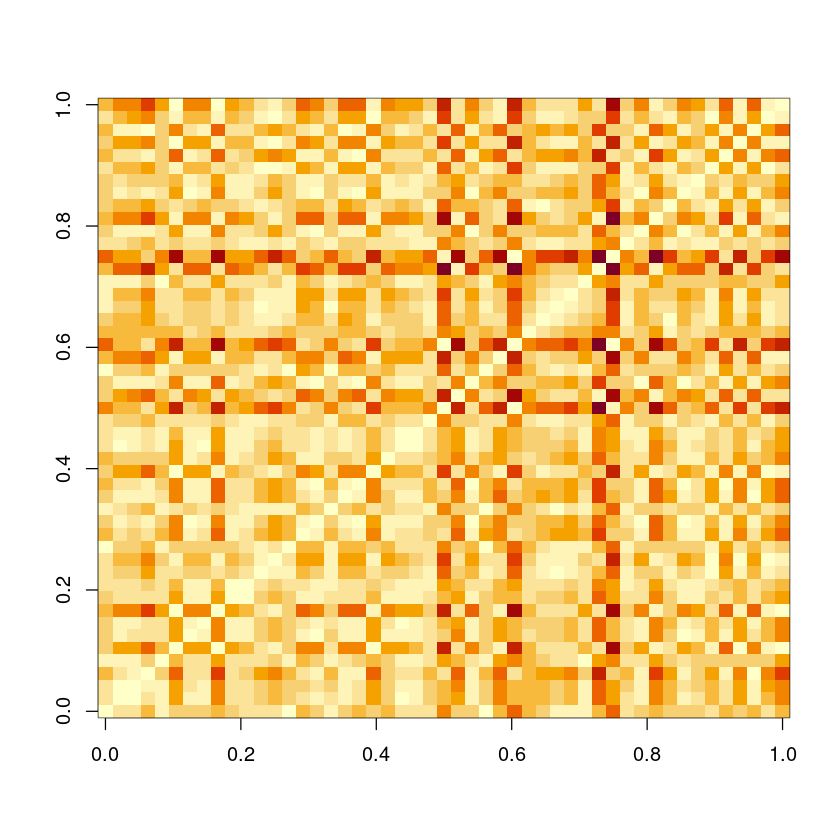

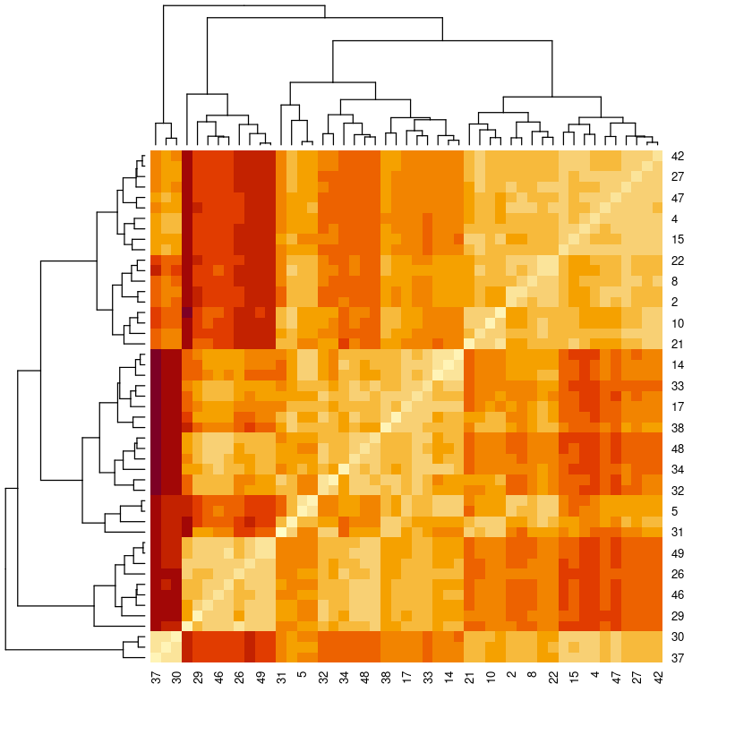

```r
#Visulization of a distance matrix
image(edist)
heatmap(edist)
```

Find the Mahalanobis distance matrix. Please use the sample covariancea matrix as the covariance matrix in the calculation.

```r
#Find the distrance matrix of manhattan distance of all cases in the sparrow bird data
 #mah.dist= dist(dat, method="Mahalanobis")
 #dist
```

# Distance Based on Proportions

When variables represent **counts** across categories (such as the number of individuals in each species, or counts of words, etc.), it is often useful to convert them into **proportions** or **percentages** for distance calculation.

A **proportion** $p$ is a decimal between 0 and 1, representing the relative amount of a category.  
For example, the **proportion of birds that survived** could be 0.73, meaning 73% survival rate.

## Transforming Count Data

Distances for count or proportion data begin with transforming each row of count data into **relative counts**:

$$ p_{ij} = \frac{x_{ij}}{\sum_{k=1}^{K} x_{ik}} $$

so that each row (observation) sums to 1.  
This normalization ensures that comparisons between rows are based on **relative composition**, not absolute magnitude.

### 1. Total Variation (TV) or $L_1/2$ Distance

This is the most commonly used measure for proportion (or percentage) data.  
It is also equivalent to the **Bray–Curtis distance** when applied to normalized rows.

$$ d_1(\mathbf{p}, \mathbf{q}) = \frac{1}{2} \sum_{i=1}^{K} |p_i - q_i| $$

**Properties:**

- $0 \le d_1 \le 1$
- Interpretable as the **minimum amount of probability mass that must be moved** to make $\mathbf{p}$ identical to $\mathbf{q}$.
- Reduces to the same value as the **Bray–Curtis dissimilarity** when data are expressed as proportions.

### 2. Bray–Curtis Distance

The **Bray–Curtis distance** (also known as the **dissimilarity index**) is one of the most widely used metrics for ecological and compositional data.

Formula for raw counts:

Given two samples $\mathbf{x} = (x_1, x_2, \dots, x_K)$ and $\mathbf{y} = (y_1, y_2, \dots, y_K)$:

$$ d_{\text{BC}}(\mathbf{x}, \mathbf{y}) = \frac{\sum_{i=1}^{K} |x_i - y_i|}{\sum_{i=1}^{K} (x_i + y_i)} $$

If data are proportions (each row sums to 1):

$$ d_{\text{BC}}(\mathbf{p}, \mathbf{q}) = \frac{1}{2} \sum_{i=1}^{K} |p_i - q_i| $$

Thus, for normalized data, the **Bray–Curtis distance** is exactly equal to the **Total Variation (TV)** or **$L_1/2$ distance**.

Bray–Curtis distance captures differences in relative composition between samples. It is especially appropriate for ecological, microbiome, or environmental datasets where absolute abundance is less important than relative abundance.

Properties:

- $0 \le d_{\text{BC}} \le 1$
- $d_{\text{BC}} = 0$ → identical compositions
- $d_{\text{BC}} = 1$ → completely distinct compositions
- Not a true metric (it doesn’t satisfy the triangle inequality), but widely used in ecological and environmental data.

R package to find the distance between proportion / count data

library(ade4)

Function: dist.prop

Example: 1. find the distance matrix of the observations in the propdata.txt, using prop.dist function in R.  
2. Use the formula to find the distance between the 12th and 28th observation, using the distance of proportions.

```r
loc = "propdata.txt"
dat.prop = read.table(loc, header=0, skip=3)
head(dat.prop)
#Load the data
library(ade4)
```

A data.frame: 6 × 6

|  | V1 <chr> | V2 <dbl> | V3 <dbl> | V4 <dbl> | V5 <dbl> | V6 <dbl> |
| --- | --- | --- | --- | --- | --- | --- |
| 1 | s1 | 0.000 | 0.074 | 0.333 | 0.519 | 0.074 |
| 2 | s2 | 0.481 | 0.074 | 0.241 | 0.204 | 0.000 |
| 3 | s3 | 0.000 | 0.370 | 0.333 | 0.296 | 0.000 |
| 4 | s4 | 0.000 | 0.000 | 0.833 | 0.167 | 0.000 |
| 5 | s5 | 0.342 | 0.132 | 0.079 | 0.263 | 0.184 |
| 6 | s6 | 0.360 | 0.244 | 0.151 | 0.186 | 0.058 |

```r
?dist.prop
```

0.17

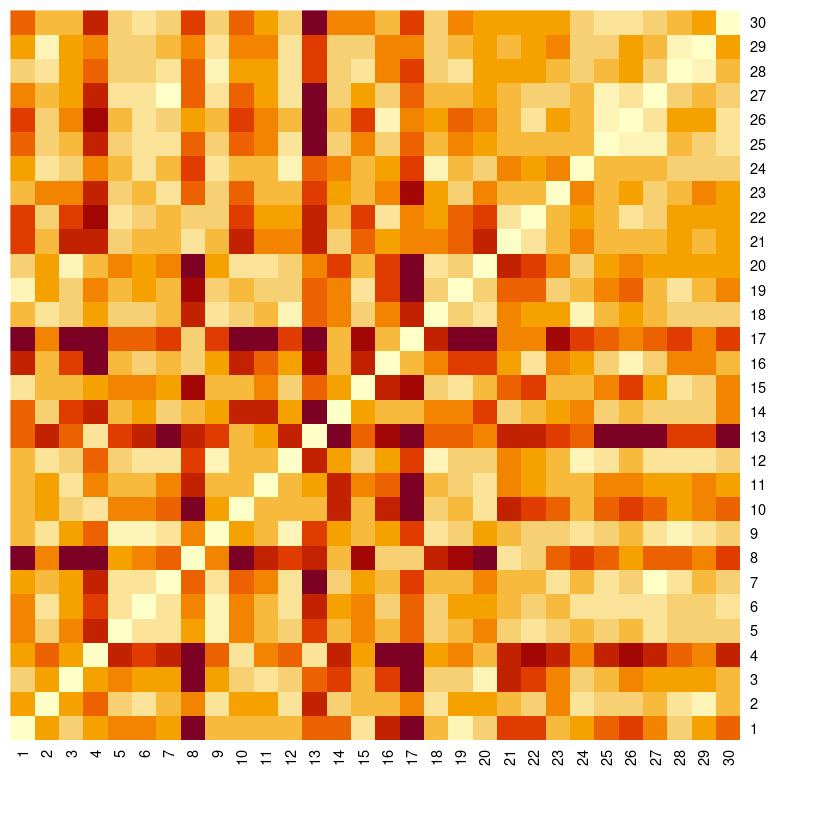

```r
dat.prop0 = dat.prop[,-1]

#dist.prop:
#Computation of Distance Matrices of Percentage Data

dis.mat = dist.prop(dat.prop0, method  = 1)
dis.Mat = as.matrix(dis.mat)

#image(dis.Mat)

#round(dis.Mat, 1)

heatmap(dis.Mat, Colv=NA, Rowv=NA, scale='none')
#library(gplots)
#heatmap.2(dis.Mat, dendrogram='none', Rowv=TRUE, Colv=TRUE,trace='none')

dis.Mat[12,28]
```

```r
library(vegan)

# Convert counts to proportions
P = dat.prop0 / rowSums(dat.prop0)

# Compute Bray–Curtis distance matrix
DBC.nat = vegdist(P, method = "bray")

# View distance between 12th and 28th observations
as.matrix(DBC.nat)[12, 28]
```

0.17

```r
#question 2

d12.28 = 0.5*sum( abs(dat.prop0[12,] - dat.prop0[28,]) )
d12.28
dis.Mat[12, 28]

#Use the manhantan distance to find the distance matrix
md.mat = dist( dat.prop0, method="manhattan")
md.Mat = as.matrix(md.mat)/2
#Distance between proportions for 12th observation and the 28th observation.
md.Mat[12,28]
```

0.17

0.17

0.17

### Example: Squared Mahalanobis Distance Matrix

**Task:**  
Find the **squared Mahalanobis distance matrix** of all **survived cases** in the *Sparrow* dataset.  
Assume that the **sample covariance matrix** of the survived group is used as an estimate of the unknown population covariance matrix.

21

13.0899123708175

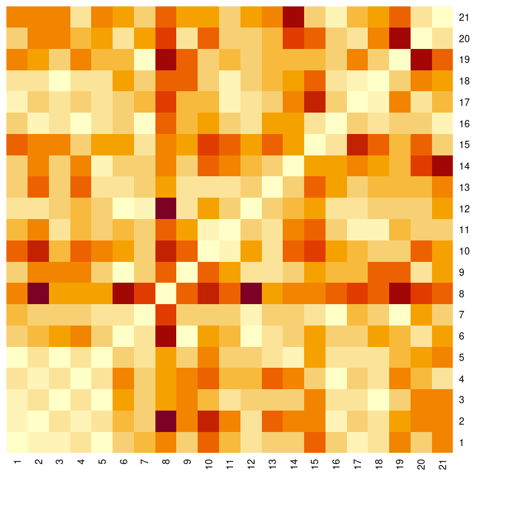

```r
#Data for sparrow of survived cases, without the categorical variable
sdat = sparrow1.dat[ sparrow1.dat$Survivorship=="S", -1]
#sdat

length(sdat[,1])
#Find the sample covariance matrix for all survived cases
covMat = cov(sdat)

#Find the dist matrix for the squared Mahalanobis dist
#Margin = 1:  line by line, by rows
#Returns the squared Mahalanobis distance by mahalanobis function in R
m.dist.mat= apply(sdat, MARGIN=1, function(i) { mahalanobis(sdat, i, cov= covMat) }  )

#round(m.dist.mat, 2)

#The squared mahalanobis distance between the second survived bird and the third one is 6.28
#The mahalanobis distance between the second survived bird and the third one is \sqrt (6.28)

#The squared mahalanobis distance between the third survived bird and the ninth one is 13.09
#The Mahalanobis Distance between the 3rd and 9th observations is 3.61799806522889, sqrt of the squared distance.
m.dist.mat[3,9]

#Visulize it
heatmap(m.dist.mat, Colv=NA, Rowv=NA, scale='none')
```

A matrix: 1 × 1 of type dbl

| 13.09 |
| --- |

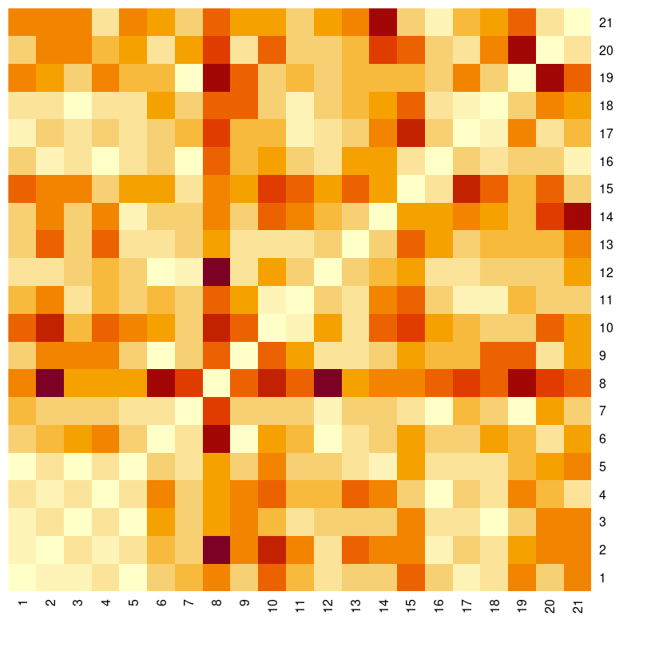

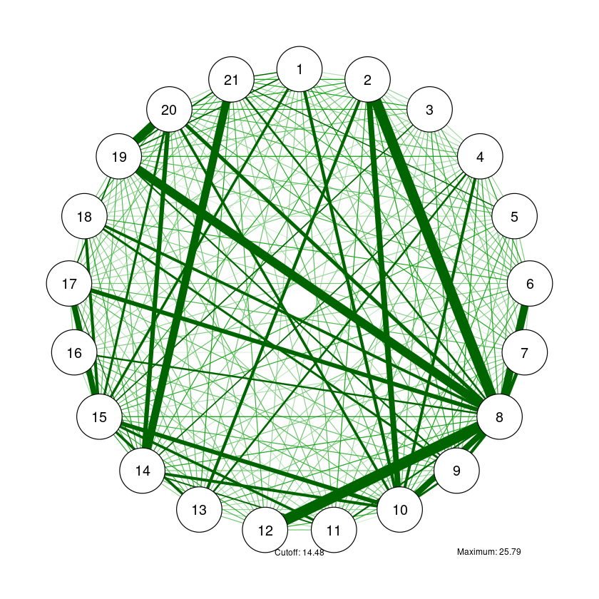

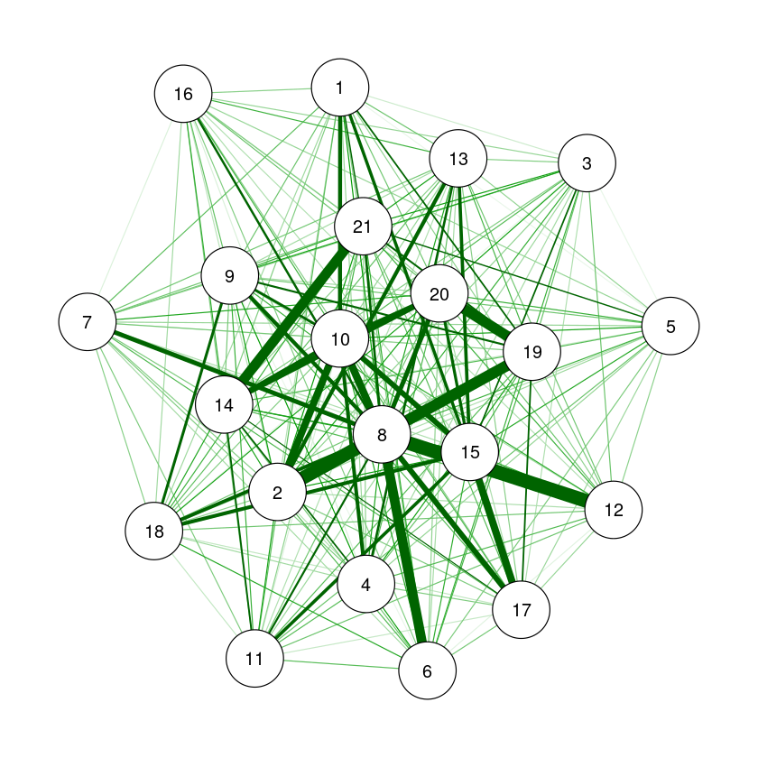

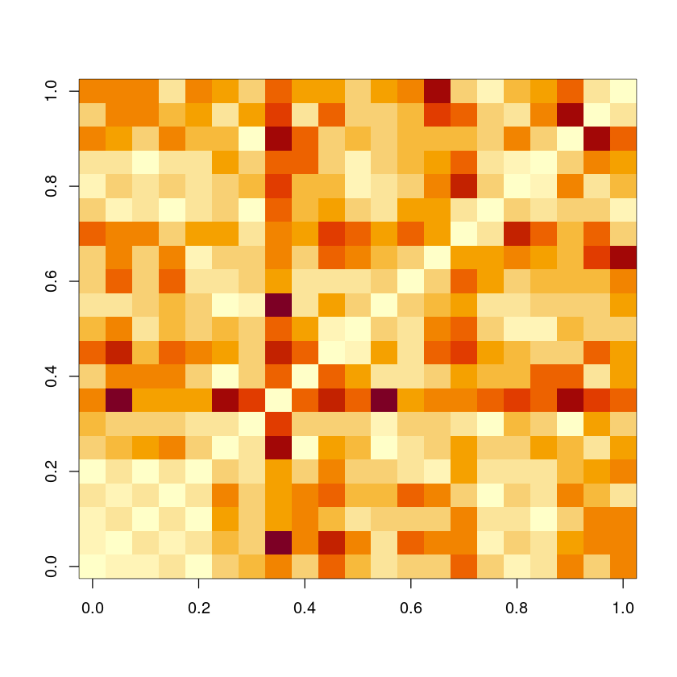

```r
#Data for sparrow of survived cases, without the categorical variable
sdat = sparrow1.dat[ sparrow1.dat$Survivorship=="S", -1]
#sdat

#Find the sample covariance matrix for all survived cases
covMat = cov(sdat)

#Find the dist matrix for the squared Mahalanobis dist
#Margin = 1:  line by line
#Returns the squared Mahalanobis distance by mahalanobis function in R
m.dist.mat= apply(sdat, MARGIN=1, function(i) { mahalanobis(sdat, i, cov= covMat) }  )

#round(m.dist.mat,1)

#Visulize it
heatmap(m.dist.mat, Colv=NA, Rowv=NA, scale='none')

#Find the mahalanobis distance between the 3rd observation and 9th observation

vdiffence = as.vector(as.numeric(sdat[3,] - sdat[9,]))
#vdiffence
invMat = solve(covMat)
#invMat
#t(vdiffence )%*%solve(covMat)%*% vdiffence
round(t(vdiffence)%*%invMat%*%vdiffence,2)

#The squared Mahalanobis Distance between the 3rd and 9th observations is 13.08991.
#The Mahalanobis Distance between the 3rd and 9th observations is 3.61799806522889, sqrt of the squared distance.

#There are some  other opions for the covariance matrix
#if there are multiple groups, and the population covariance matrices are not the same,
#more than just using the covariance matrix of the whole data, or for one or two groups.


#qgraph to visulize the distance matrix
library(qgraph)
#?qgraph
qgraph(m.dist.mat, details=TRUE )
qgraph(m.dist.mat, layout='spring' )

image(m.dist.mat)
```

## The Mantel Randomization Test

Mantel (1967) introduced a valuable statistical procedure for comparing two distance or similarity matrices, providing an effective way to detect patterns of spatial or temporal association. Originally developed to identify clustering of diseases in both space and time, the Mantel test examines whether objects that are close in one domain (e.g., spatial location) also tend to be close in another (e.g., time of occurrence or genetic similarity).

Unlike traditional correlation methods that assess relationships between two individual variables, the Mantel test evaluates the correlation between two matrices, each summarizing pairwise distances or similarities among the same set of observations.

Let $D^{(1)} = [d^{(1)}_{ij}]$ and $D^{(2)} = [d^{(2)}_{ij}]$ denote two $n \times n$ distance (or similarity) matrices computed from the same $n$ objects. The Mantel statistic is defined as the Pearson correlation between the corresponding upper (or lower) triangular elements of the two matrices:

$$ r_M = \frac{ \sum_{i<j} (d^{(1)}_{ij} - \bar{d}^{(1)})(d^{(2)}_{ij} - \bar{d}^{(2)}) }{ \sqrt{ \sum_{i<j} (d^{(1)}_{ij} - \bar{d}^{(1)})^2 \sum_{i<j} (d^{(2)}_{ij} - \bar{d}^{(2)})^2 } }. $$

To assess significance, one matrix (say $D^{(2)}$) is randomly permuted many times, and $r_M$ is recalculated for each permutation. The $p$-value is obtained as the proportion of permuted correlations that are greater than or equal to the observed $r_M$.

A significant Mantel correlation indicates that the distances in one matrix are systematically related to those in the other. Specifically, as distances between samples increase in one matrix, they tend to increase in the other as well. This makes the Mantel test particularly useful when relationships are encoded as pairwise dissimilarities rather than raw variables.

**Example:**  
The Mantel test has wide application in ecology, genetics, and epidemiology. In ecological research, it is commonly used to test for *isolation by distance*—whether genetic differentiation among populations increases with geographic separation. Here, one matrix represents genetic distances derived from molecular markers, while the other contains geographical distances between sampling sites. A significant result supports a spatial structure in genetic variation.

In epidemiology, the Mantel test can be used to examine whether disease cases that occur close together spatially also occur close in time, suggesting possible contagion or shared environmental exposure.

The `ade4` package in R provides a convenient function `mantel.rtest()` to perform the Mantel test on two distance or similarity matrices. This function computes the Mantel statistic (correlation between matrices) and assesses its significance using permutation tests.

```r
#libarary ade4
library(ade4)

ozone = read.table("https://stats.idre.ucla.edu/stat/r/faq/ozone.csv", sep=",", header=T)

#The purpose is to see if the distance in the pollution (ozone) level and the geographical distance are related or not.
#We can use Mantel test

#distance objects returned by dist function
g.dist = dist(cbind(ozone$Lon, ozone$Lat))
ozone.dist = dist(ozone$Av8top)

set.seed(217)
# class 'dist' expected in the input
mantel.rtest(g.dist, ozone.dist, nrepet = 9000)

#Simulated p-value: 0.03199644
#Reject H0 (not related).  There is sufficient evidence in the data to
#support H1 that the distance in ozone is related to the geographical distance.

#The correlation between two dist object is 0.1636308 which suggests a positive association
#between the matrix entries. Thus,smaller differences in ozone are generally observed among pairs of
#stations that are closer to each other than those farther apart.
```

```
Monte-Carlo test
Call: mantel.rtest(m1 = g.dist, m2 = ozone.dist, nrepet = 9000)

Observation: 0.1636308

Based on 9000 replicates
Simulated p-value: 0.03199644
Alternative hypothesis: greater

    Std.Obs Expectation    Variance
2.197459483 0.001180518 0.005465113
```

## Multivariate Outliers

Outliers are data points that deviate significantly from the overall pattern of the dataset. These points lie outside the “normal” range of the data. In multivariate analysis, outliers can be detected using the **Mahalanobis distance**, which measures the distance of each observation from the center of the multivariate distribution (or the center of the nearest group).

The **squared Mahalanobis distances** are compared to a $\chi^2$ distribution with $p$ degrees of freedom, where $p$ is the number of variables. Observations with unusually large Mahalanobis distances relative to this distribution are considered potential multivariate outliers.

**Example:** Identify outliers in the sparrow dataset using all quantitative variables.

1. Using the sample covariance of all quantitative variables as the covariance matrix, calculate the squared Mahalanobis distance between each observation and the multivariate mean (the center of all observations).
2. Compute the p-value for each Mahalanobis distance using the $\chi^2$ distribution with $p$ degrees of freedom.
3. Identify observations as outliers if their p-value is below 0.01, and report the total number of outliers.
4. Optionally, repeat the analysis for a subset of observations, such as **survival cases only**.

```r
#Load the data

#If all data are from a group, ...

loc1 ="~//distribute_files//data//Bumpus_sparrows.csv"
sparrow1.dat = read.csv( loc1,  header = 1 )
head(sparrow1.dat)

#Data matrix
dat = sparrow1.dat[, -1]

#Step 1 : calculate the Manhanobis distance to the center of the data
mean.vec = colMeans(dat)
#mean.vec
cov.dat = cov(dat)

#squared mahalanobis distance
dist.vec = mahalanobis(dat, center=mean.vec, cov= cov.dat)

#hist(dist.vec)
#If the data are from a multivariate normal , the distribution of squared mahalanobis distance has a Chisq distribution
#with the degrees of freedom = the number of variables.

#If the level of sigificance = 0.01, if p-value of an observation is below the level of sigificance,
#then it is identified as an outlier based on this method.

#P( Chisq distribution > the observed distance)
pval.vect = 1 -  pchisq( dist.vec, df= 5 )
round(pval.vect, 5)

#The number of outliers at the significnace level of 0.01
sum(pval.vect < 0.01)

#See which is (are) outliers
dat[pval.vect < 0.01, ]

#The 31th observation is an outler :  162, 239, 30.3, 18, 23.1
```

A data.frame: 6 × 6

|  | Survivorship <chr> | Total_length <int> | Alar_extent <int> | L_beak_head <dbl> | L_humerous <dbl> | L_keel_sternum <dbl> |
| --- | --- | --- | --- | --- | --- | --- |
| 1 | S | 156 | 245 | 31.6 | 18.5 | 20.5 |
| 2 | S | 154 | 240 | 30.4 | 17.9 | 19.6 |
| 3 | S | 153 | 240 | 31.0 | 18.4 | 20.6 |
| 4 | S | 153 | 236 | 30.9 | 17.7 | 20.2 |
| 5 | S | 155 | 243 | 31.5 | 18.6 | 20.3 |
| 6 | S | 163 | 247 | 32.0 | 19.0 | 20.9 |

1. 0.62807

2. 0.57812

3. 0.62139

4. 0.66331

5. 0.73234

6. 0.67294

7. 0.83766

8. 0.04648

9. 0.51512

10. 0.22219

11. 0.71711

12. 0.7545

13. 0.80606

14. 0.35823

15. 0.48601

16. 0.97386

17. 0.84826

18. 0.53974

19. 0.18788

20. 0.43235

21. 0.35741

22. 0.6843

23. 0.95382

24. 0.59119

25. 0.33973

26. 0.13056

27. 0.67475

28. 0.22445

29. 0.04996

30. 0.41613

31. 0.00194

32. 0.78989

33. 0.76387

34. 0.03176

35. 0.47813

36. 0.24281

37. 0.20453

38. 0.80902

39. 0.67928

40. 0.2028

41. 0.20434

42. 0.7852

43. 0.75836

44. 0.78862

45. 0.78857

46. 0.44527

47. 0.28337

48. 0.46581

49. 0.47123

1

A data.frame: 1 × 5

|  | Total_length <int> | Alar_extent <int> | L_beak_head <dbl> | L_humerous <dbl> | L_keel_sternum <dbl> |
| --- | --- | --- | --- | --- | --- |
| 31 | 162 | 239 | 30.3 | 18 | 23.1 |